# M4_Lab3

Emily Shepherd

2023-02-03

First, I went through the steps in the video to make several simple plots. The first plot that I made explored the relationship between income per capita and income inequality. It did not seem like it was an interesting plot, so I switched variables.

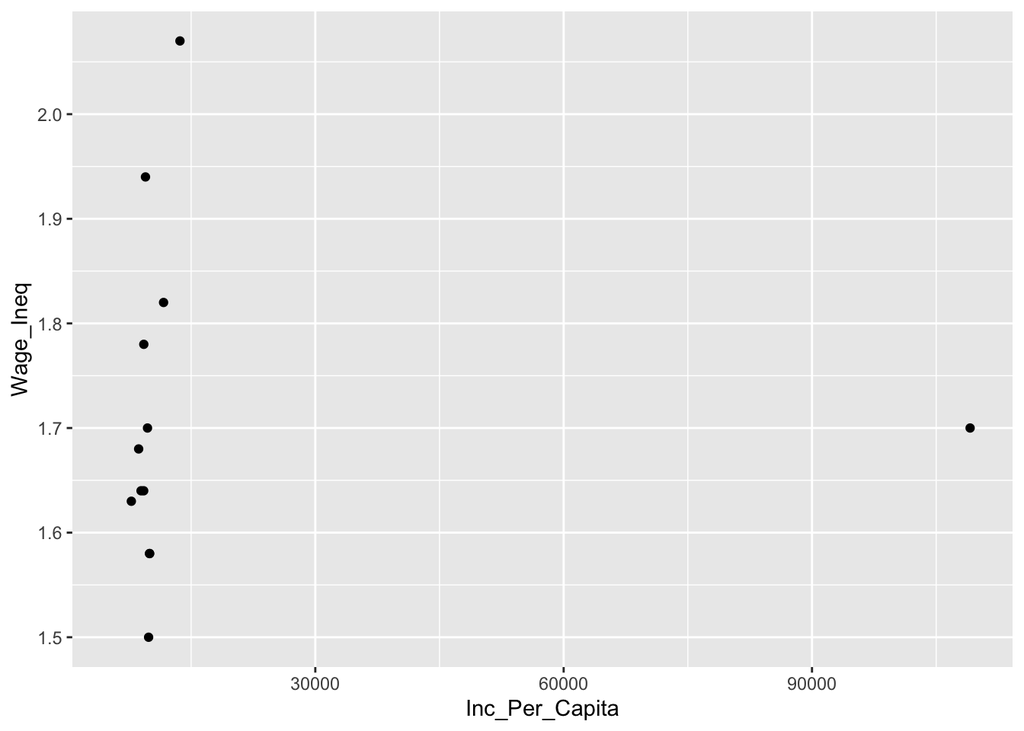

Next, I created a simple plot of wage inequality versus unionization.

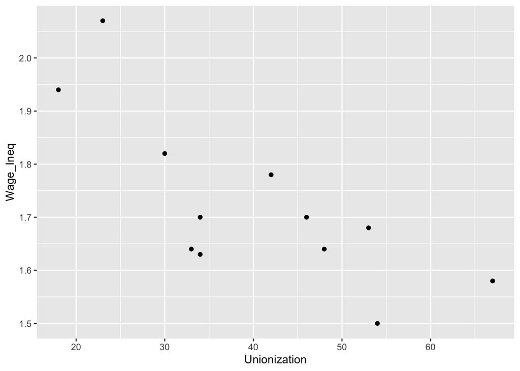

The plot displayed a much more interesting relationship, so I decided to plot the regression line on the scatterplot. I created two different plots. One that showed the standard error and the other did not.

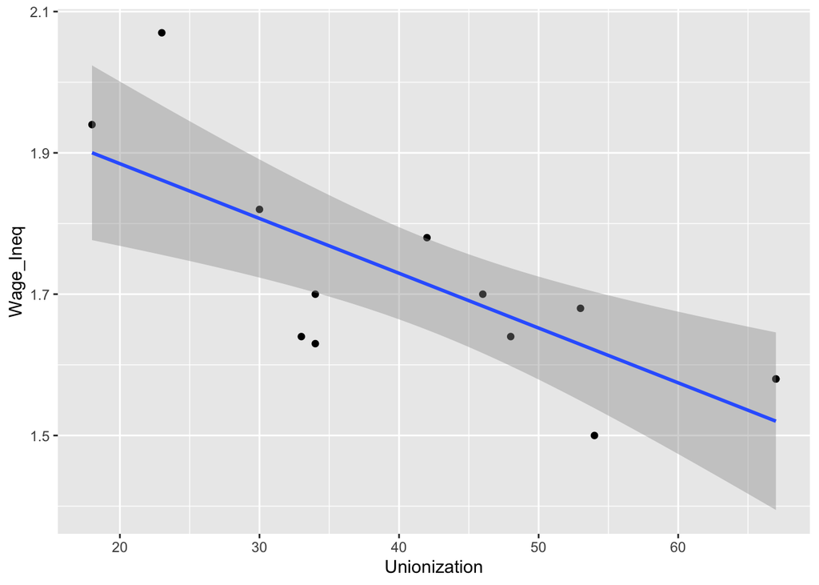

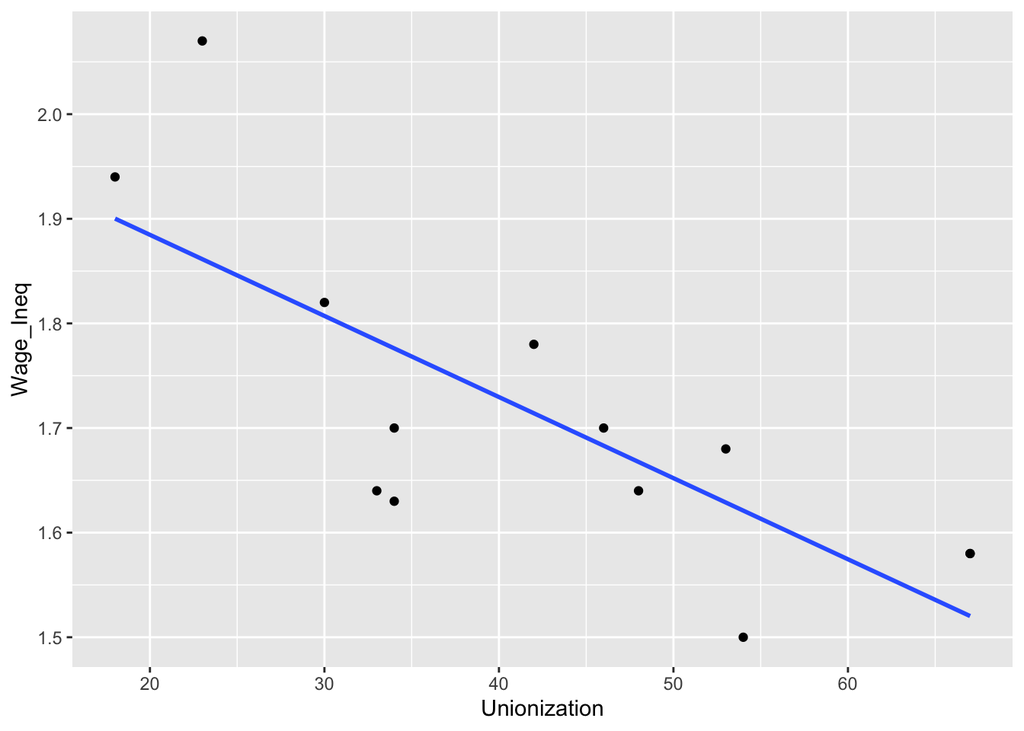

I wondered if there was a difference in countries based on their electoral system. I decided to color the plots based on whether the countries had majoratarian or proportional rule. I decided to use the Viridis color scheme, because it is useful for people who are color blind. However, I felt that the yellow was hard to see compared to the purple.

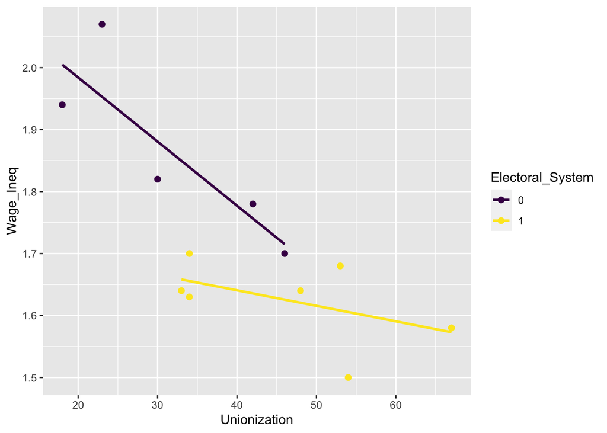

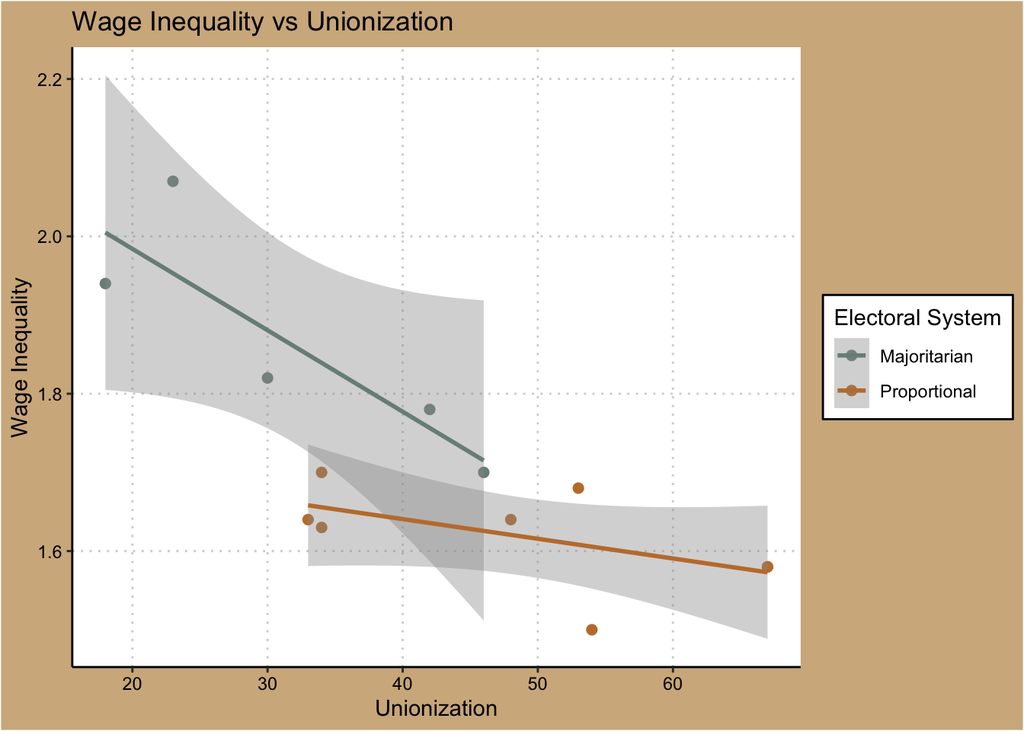

Because I had so few data points, the standard errors took up most of the plot, and I felt like my graph was less clear with standard errors shown. My last plot was the same as the previous, but only the regression lines are shown, not the standard errors.

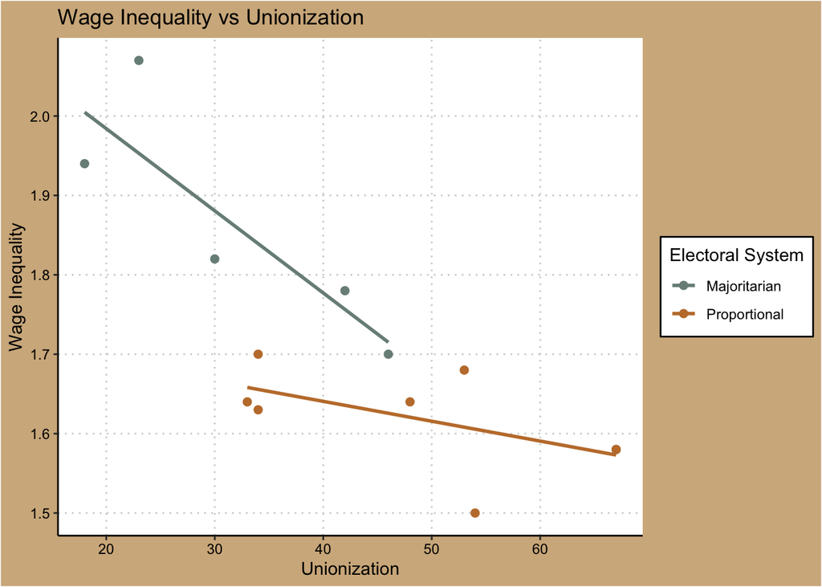